# Exercises with Solutions

Michael Mayer

2022-05-17

# Chapter 1: Basics and Linear Models

## Exercise on linear regression

```r
library(tidyverse)

dia <- diamonds %>%
  mutate_at(
    c("color", "cut", "clarity"),
    function(z) factor(z, ordered = FALSE)
  )

fit <- lm(price ~ carat + color + cut + clarity, data = dia)
summary(fit)
```

```
##
## Call:
## lm(formula = price ~ carat + color + cut + clarity, data = dia)
##
## Residuals:
##      Min       1Q   Median       3Q      Max
## -16813.5   -680.4   -197.6    466.4  10394.9
##
## Coefficients:
##              Estimate Std. Error t value Pr(>|t|)
## (Intercept)  -7362.80      51.68 -142.46   <2e-16 ***
## carat         8886.13      12.03  738.44   <2e-16 ***
## colorE        -211.68      18.32  -11.56   <2e-16 ***
## colorF        -303.31      18.51  -16.39   <2e-16 ***
## colorG        -506.20      18.12  -27.93   <2e-16 ***
## colorH        -978.70      19.27  -50.78   <2e-16 ***
## colorI       -1440.30      21.65  -66.54   <2e-16 ***
## colorJ       -2325.22      26.72  -87.01   <2e-16 ***
## cutGood        655.77      33.63   19.50   <2e-16 ***
## cutVery Good   848.72      31.28   27.14   <2e-16 ***
## cutPremium     869.40      30.93   28.11   <2e-16 ***
## cutIdeal       998.25      30.66   32.56   <2e-16 ***
## claritySI2    2625.95      44.79   58.63   <2e-16 ***
## claritySI1    3573.69      44.60   80.13   <2e-16 ***
## clarityVS2    4217.83      44.84   94.06   <2e-16 ***
## clarityVS1    4534.88      45.54   99.59   <2e-16 ***
## clarityVVS2   4967.20      46.89  105.93   <2e-16 ***
## clarityVVS1   5072.03      48.21  105.20   <2e-16 ***
## clarityIF     5419.65      52.14  103.95   <2e-16 ***
## ---
## Signif. codes:  0 '***' 0.001 '**' 0.01 '*' 0.05 '.' 0.1 ' ' 1
##
## Residual standard error: 1157 on 53921 degrees of freedom
## Multiple R-squared:  0.9159, Adjusted R-squared:  0.9159
## F-statistic: 3.264e+04 on 18 and 53921 DF,  p-value: < 2.2e-16
```

**Comments**

- **Model quality:** About 92% of price variations are explained by covariates. Typical prediction error is 1157 USD.
- **Effects:** All effects point into the intuitively right direction (larger stones are more expensive, worse color are less expensive etc.)
- **Practical perspective:** Additivity in color, cut and clarity are not making sense. Their effects should get larger with larger diamond size. This can be solved by adding interaction terms with carat or, much easier, to switch to a logarithmic response.

## Exercise on GLMs

```r
library(tidyverse)

dia <- diamonds %>%
  mutate_at(
    c("color", "cut", "clarity"),
    function(z) factor(z, ordered = FALSE)
  )

fit <- glm(
  price ~ log(carat) + color + cut + clarity,
  data = dia,
  family = Gamma(link = "log")
)
summary(fit)
```

```
##
## Call:
## glm(formula = price ~ log(carat) + color + cut + clarity, family = Gamma(link = "log"),
##     data = dia)
##
## Deviance Residuals:
##      Min        1Q    Median        3Q       Max
## -0.88250  -0.09422  -0.00927   0.07582   2.77408
##
## Coefficients:
##               Estimate Std. Error t value Pr(>|t|)
## (Intercept)   7.893253   0.006005 1314.39   <2e-16 ***
## log(carat)    1.881552   0.001177 1598.30   <2e-16 ***
## colorE       -0.056294   0.002209  -25.48   <2e-16 ***
## colorF       -0.096365   0.002234  -43.14   <2e-16 ***
## colorG       -0.163526   0.002187  -74.79   <2e-16 ***
## colorH       -0.253495   0.002320 -109.25   <2e-16 ***
## colorI       -0.374271   0.002599 -144.01   <2e-16 ***
## colorJ       -0.511085   0.003206 -159.43   <2e-16 ***
## cutGood       0.071682   0.004057   17.67   <2e-16 ***
## cutVery Good  0.108277   0.003774   28.69   <2e-16 ***
## cutPremium    0.132433   0.003732   35.48   <2e-16 ***
## cutIdeal      0.153177   0.003700   41.40   <2e-16 ***
## claritySI2    0.410246   0.005400   75.97   <2e-16 ***
## claritySI1    0.572741   0.005369  106.67   <2e-16 ***
## clarityVS2    0.722777   0.005400  133.86   <2e-16 ***
## clarityVS1    0.792355   0.005482  144.54   <2e-16 ***
## clarityVVS2   0.930734   0.005651  164.71   <2e-16 ***
## clarityVVS1   1.001689   0.005814  172.28   <2e-16 ***
## clarityIF     1.098156   0.006289  174.62   <2e-16 ***
## ---
## Signif. codes:  0 '***' 0.001 '**' 0.01 '*' 0.05 '.' 0.1 ' ' 1
##
## (Dispersion parameter for Gamma family taken to be 0.01947099)
##
##     Null deviance: 52897.70  on 53939  degrees of freedom
## Residual deviance:   978.68  on 53921  degrees of freedom
## AIC: 777047
##
## Number of Fisher Scoring iterations: 4
```

```r
mean(dia$price) / mean(predict(fit, type = "response")) - 1
```

```
## [1] 0.003362972
```

**Comment:** The coefficients are very similar to the linear regression with log(price) as response. This makes sense as we interpret the coefficients in the same way! The bias is only 0.3%, i.e., much smaller than the 3% of the OLS with log(price) as response. Still, because the log is not the natural link of the Gamma regression, the bias is not exactly 0.

# Chapter 2: Model Selection and Validation

## Exercise 1

```r
library(tidyverse)
library(FNN)
library(splitTools)
library(MetricsWeighted)

# Covariates
x <- c("carat", "color", "cut", "clarity")

dia <- unique(diamonds[, c("price", x)])

# Split diamonds into 90% for training and 10% for testing
ix <- partition(
  dia$price,
  p = c(train = 0.9, test = 0.1),
  seed = 9838,
  type = "basic"
)

train <- dia[ix$train, ]
test <- dia[ix$test, ]

y_train <- train$price
y_test <- test$price

# Standardize training data
X_train <- scale(data.matrix(train[, x]))

# Apply training scale to test data
X_test <- scale(
  data.matrix(test[, x]),
  center = attr(X_train, "scaled:center"),
  scale = attr(X_train, "scaled:scale")
)

# Split training data into folds
nfolds <- 5
folds <- create_folds(y_train, k = nfolds, seed = 9838, type = "basic")

# Cross-validation performance of k-nearest-neighbour for k = 1-20
paramGrid <- data.frame(RMSE = NA, k = 1:20)

for (i in 1:nrow(paramGrid)) {
  k <- paramGrid[i, "k"]
  scores <- c()

  for (fold in folds) {
    pred <- knn.reg(
      X_train[fold, ],
      test = X_train[-fold, ],
      k = k,
      y = y_train[fold]
    )$pred
    scores[length(scores) + 1] <- rmse(y_train[-fold], pred)
  }
  paramGrid[i, "RMSE"] <- mean(scores)
}

# Best k along with its CV performance
paramGrid[order(paramGrid$RMSE)[1], ]
```

|  | RMSE | k |
| --- | --- | --- |
| 5 | 714.381 | 5 |

```r
# Cross-validation performance of linear regression
rmse_reg <- c()

for (fold in folds) {
  fit <- lm(
    price ~ log(carat) + color + cut + clarity,
    data = train[fold, ]
  )
  pred <- predict(fit, newdata = train[-fold, ])
  rmse_reg[length(rmse_reg) + 1] <- rmse(y_train[-fold], pred)
}
(rmse_reg <- mean(rmse_reg))
```

```
## [1] 1942.002
```

```r
# The overall best model is 5-nearest-neighbour
pred <- knn.reg(X_train, test = X_test, k = 5, y = y_train)$pred

# Test performance for the best model
rmse(y_test, pred)
```

```
## [1] 706.1934
```

**Comments:** The test performance of the best model (5-NN) seems clearly worse than the one without deduplication (~700 USD RMSE vs ~600). CV performance well corresponds to test performance. Overall, this is probably the more realistic performance than the one obtained from the original data set. Still, as certain rows could be identical by chance, our deduplication approach might be slightly too conservative. The true performance will probably be somewhere between the two approaches.

## Exercise 2

```r
library(tidyverse)
library(splitTools)
library(MetricsWeighted)

dia <- diamonds %>%
  mutate_at(
    c("color", "cut", "clarity"),
    function(z) factor(z, ordered = FALSE)
  )

# Split diamonds into 90% for training and 10% for testing
ix <- partition(
  dia$price,
  p = c(train = 0.9, test = 0.1),
  seed = 9838,
  type = "basic"
)

train <- dia[ix$train, ]
test <- dia[ix$test, ]

# manual GridSearchCV
nfolds <- 5
folds <- create_folds(train$price, k = nfolds, seed = 9838, type = "basic")
paramGrid <- data.frame(Deviance = NA, k = 1:12)

for (i in 1:nrow(paramGrid)) {
  k <- paramGrid[i, "k"]
  scores <- c()

  for (fold in folds) {
    fit <- glm(
      price ~ poly(log(carat), degree = k) + color + cut + clarity,
      data = train[fold, ],
      family = Gamma(link = "log")
    )
    pred <- predict(fit, train[-fold, ], type = "response")
    scores[length(scores) + 1] <- deviance_gamma(train$price[-fold], pred)
  }
  paramGrid[i, "Deviance"] <- mean(scores)
}

paramGrid
```

| Deviance | k |
| --- | --- |
| 0.01796933 | 1 |
| 0.01779899 | 2 |
| 0.01608336 | 3 |
| 0.01608082 | 4 |
| 0.01602549 | 5 |
| 0.01588515 | 6 |
| 0.01580066 | 7 |
| 0.01575480 | 8 |
| 0.01578505 | 9 |
| 0.01592406 | 10 |

[output cut: 2 more lines]

```r
# Fit model on full training data
fit <- glm(
  price ~ poly(log(carat), degree = 8) + color + cut + clarity,
  data = train,
  family = Gamma(link = "log")
)

# Evaluate on test
pred <- predict(fit, test, type = "response")
deviance_gamma(test$price, pred) # 0.01710076
```

```
## [1] 0.01710076
```

```r
r_squared_gamma(test$price, pred) # 0.982464 relative deviance gain
```

```
## [1] 0.982464
```

**Comments:** The optimal degree seems to be 8 with a CV deviance of 0.01575. There seems to be some amount of CV overfit as the deviance evaluated on the test data is worse. Caution: Instead of using such high degree polynomial, it is almost always better to use regression splines.

## Exercise 3 (optional)

Solution not shown here.

# Chapter 3: Trees

## Exercises on Random Forests

### Exercise 1

```r
library(tidyverse)
library(splitTools)
library(ranger)
library(MetricsWeighted)

dia <- diamonds %>%
  mutate(log_carat = log(carat))

# Train/test split
ix <- partition(dia$price, p = c(train = 0.8, test = 0.2), seed = 9838)

fit <- ranger(
  price ~ log_carat + color + cut + clarity,
  num.trees = 500,
  data = dia[ix$train, ],
  importance = "impurity",
  seed = 83
)
fit
```

```
## Ranger result
##
## Call:
##  ranger(price ~ log_carat + color + cut + clarity, num.trees = 500,      data = dia[ix$train, ], importance = "impurity", seed = 83)
##
## Type:                             Regression
## Number of trees:                  500
## Sample size:                      43149
## Number of independent variables:  4
## Mtry:                             2
## Target node size:                 5
## Variable importance mode:         impurity
## Splitrule:                        variance
## OOB prediction error (MSE):       306227.9
## R squared (OOB):                  0.9807009
```

```r
# Performance on test data
pred <- predict(fit, dia[ix$test, ])$predictions
rmse(dia$price[ix$test], pred)
```

```
## [1] 556.3328
```

**Comment:* The results are essentially identical because log is a monotonic transformation. Differences might come from implementation tricks.

### Exercise 2

```r
library(tidyverse)
library(splitTools)
library(ranger)
library(flashlight)
library(MetricsWeighted)
library(insuranceData)

data(dataCar)

# Train/test split (stratified on response)
ix <- partition(dataCar$clm, p = c(train = 0.8, test = 0.2), seed = 9838)

# Instead of systematic grid search, manually select good tree depth by OOB
fit <- ranger(
  clm ~ veh_value + veh_body + veh_age + gender + area + agecat,
  data = dataCar[ix$train, ],
  probability = TRUE,
  max.depth = 5,
  importance = "impurity"
)
fit # OOB prediction using Brier score (= MSE) 0.06340884
```

```
## Ranger result
##
## Call:
##  ranger(clm ~ veh_value + veh_body + veh_age + gender + area +      agecat, data = dataCar[ix$train, ], probability = TRUE, max.depth = 5,      importance = "impurity")
##
## Type:                             Probability estimation
## Number of trees:                  500
## Sample size:                      54284
## Number of independent variables:  6
## Mtry:                             2
## Target node size:                 10
## Variable importance mode:         impurity
## Splitrule:                        gini
## OOB prediction error (Brier s.):  0.06340388
```

```r
# Note: Brier score is the same as the MSE, applied to binary data. It is
# not a bad evaluation criterion in such situation,
# so we will use this within this example.
pred <- predict(fit, dataCar[ix$test, ])$predictions[, 2]
mse(dataCar[ix$test, "clm"], pred)  # 0.06337011
```

```
## [1] 0.06337846
```

```r
r_squared(dataCar[ix$test, "clm"], pred) # 0.002069925
```

```
## [1] 0.002069925
```

```r
# Alternative to Brier score: relative log loss/deviance improvement
r_squared_bernoulli(dataCar[ix$test, "clm"], pred) # 0.004246408
```

```
## [1] 0.004246408
```

**Comment:** Test performance with small tree depth seems to be best. When studying relative performance metrics like the relative deviance gain, we can see that performance of the model is very low. TPL claims seem to be mostly determined by bad luck, which makes sense.

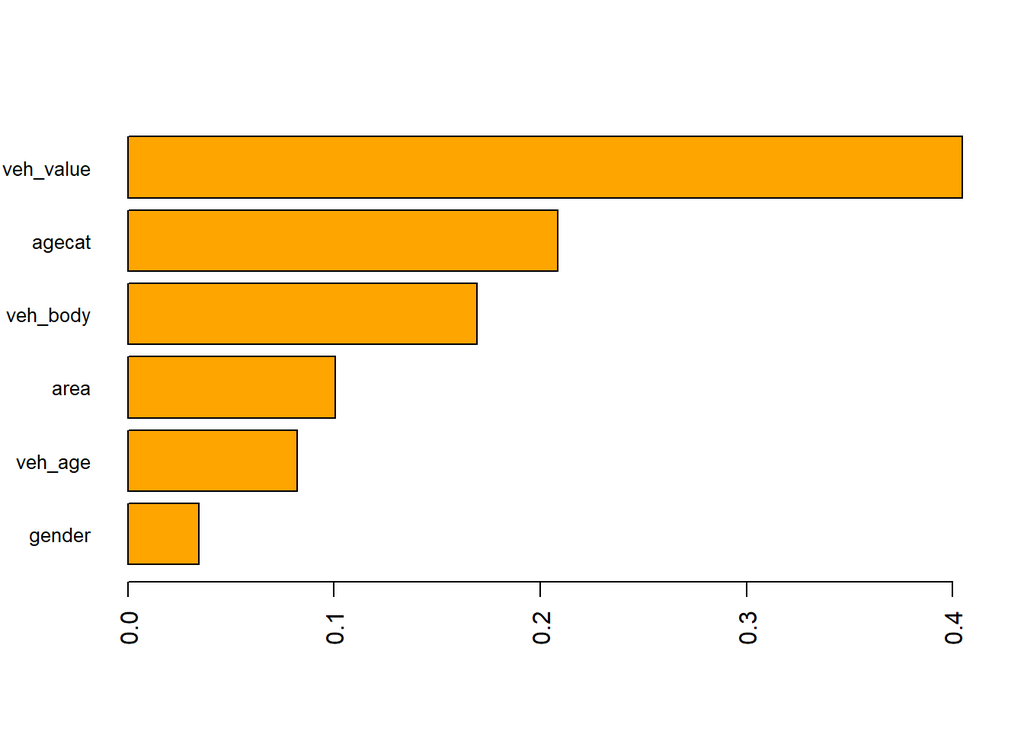

```r
# Variable importance regarding Gini improvement
imp <- sort(importance(fit))
imp <- imp / sum(imp)
barplot(imp, horiz = TRUE, col = "orange", cex.names = 0.8, las = 2)
```

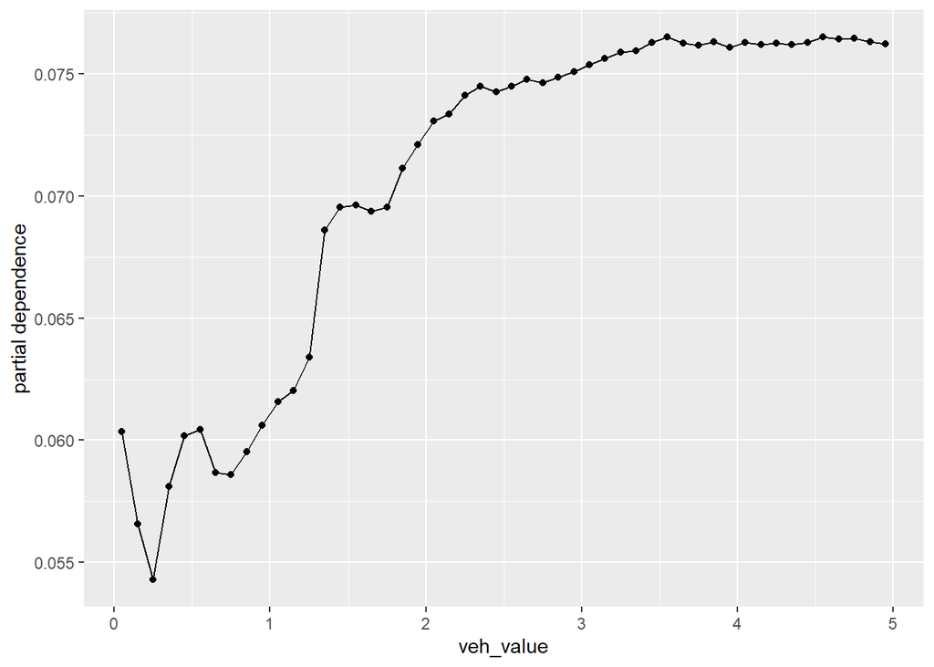

```r
# Partial dependence plot for the strongest predictor "veh_value"
fl <- flashlight(
  model = fit,
  data = dataCar[ix$train, ],
  label = "rf",
  predict_function = function(m, X) predict(m, X)$predictions[, 2]
)

light_profile(fl, v = "veh_value", breaks = seq(0, 5, by = 0.1)) %>%
  plot()
```

## Exercises on Boosting

### Exercise 1

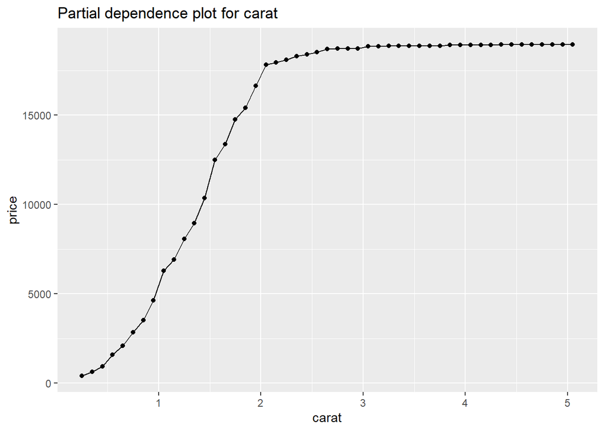

```r
library(tidyverse)
library(xgboost)
library(splitTools)

# As XGBoost does not understand strings, we encode them by integers
prep_xgb <- function(X, x = c("carat", "color", "cut", "clarity")) {
  data.matrix(X[, x, drop = FALSE])
}

# Split into train and test
ix <- partition(diamonds$price, p = c(train = 0.8, test = 0.2), seed = 9838)

y_train <- diamonds$price[ix$train]
X_train <- prep_xgb(diamonds[ix$train, ])

# XGBoost data handler
dtrain <- xgb.DMatrix(X_train, label = y_train)

# Load grid and select best iteration. If interactive, use r/gridsearch/...
grid <- readRDS("gridsearch/diamonds_xgb.rds")
grid <- grid[order(grid$cv_score), ]

# Monotone constraints for carat
params <- as.list(grid[1, -(1:3)])
params$monotone_constraints <- c(1, 0, 0, 0)

# Fit final, tuned model with monotone constraints for carat
fit <- xgb.train(
  params = params,
  data = dtrain,
  nrounds = grid[1, "iteration"]
)

# Partial dependence plot for carat
library(flashlight)

fl <- flashlight(
  model = fit,
  data = diamonds[ix$train, ],
  label = "xgb",
  predict_function = function(m, X) predict(m, prep_xgb(X))
)

light_profile(fl, v = "carat", n_bins = 40) %>%
  plot() +
  labs(title = "Partial dependence plot for carat", y = "price")
```

**Comment:** The argument is called “monotone_constraints”. For each covariate, a value 0 means no constraint, a value -1 means a negative constraints, and a value 1 means positive constraint. Applying the constraint now leads to a monotonically increasing partial dependence plot. This is extremely useful in practice. Besides monotonic constraints, also interaction constraints are possible.

### Exercise 2

```r
# We simply adapt the template from the script
library(tidyverse)
library(xgboost)
library(splitTools)
library(insuranceData)

data(dataCar)

# As XGBoost does not understand strings, we encode them by integers
prep_xgb <- function(X, x = c("veh_value", "veh_body", "veh_age",
                              "gender", "area", "agecat")) {
  data.matrix(X[, x, drop = FALSE])
}

# Split into train and test
ix <- partition(dataCar$clm, p = c(train = 0.8, test = 0.2), seed = 9838)

y_train <- dataCar$clm[ix$train]
X_train <- prep_xgb(dataCar[ix$train, ])

# XGBoost data handler
dtrain <- xgb.DMatrix(X_train, label = y_train)

# If grid search is to be run again, set tune <- TRUE
tune <- FALSE

if (tune) {
  # Use default parameters to set learning rate with suitable number of rounds
  params <- list(
    learning_rate = 0.02,
    objective = "binary:logistic",
    eval_metric = "logloss"
  )

  # Cross-validation
  cvm <- xgb.cv(
    params = params,
    data = dtrain,
    nrounds = 5000,
    nfold = 5,
    early_stopping_rounds = 20,
    showsd = FALSE,
    print_every_n = 50
  )
  cvm

  # Grid
  grid <- expand.grid(
    iteration = NA,
    cv_score = NA,
    train_score = NA,
    learning_rate = 0.02,
    objective = "binary:logistic",
    eval_metric = "logloss",
    max_depth = 3:6,
    min_child_weight = c(0.1, 1),
    colsample_bytree = c(0.8, 1),
    subsample = c(0.8, 1),
    reg_lambda = c(0, 2.5, 5, 7.5),
    reg_alpha = c(0, 4),
    # tree_method = "hist",   # when data is large
    min_split_loss = c(0, 1e-04)
  )

  # Grid search or randomized search if grid is too large
  max_size <- 20
  grid_size <- nrow(grid)
  if (grid_size > max_size) {
    grid <- grid[sample(grid_size, max_size), ]
    grid_size <- max_size
  }

  # Loop over grid and fit XGBoost with five-fold CV and early stopping
  pb <- txtProgressBar(0, grid_size, style = 3)
  for (i in seq_len(grid_size)) {
    cvm <- xgb.cv(
      params = as.list(grid[i, -(1:2)]),
      data = dtrain,
      nrounds = 5000,
      nfold = 5,
      early_stopping_rounds = 20,
      verbose = 0
    )

    # Store result
    grid[i, 1] <- cvm$best_iteration
    grid[i, 2:3] <- cvm$evaluation_log[, c(4, 2)][cvm$best_iteration]
    setTxtProgressBar(pb, i)

    # Save grid to survive hard crashs. If interactive, use r/gridsearch/...
    saveRDS(grid, file = "gridsearch/claims_xgb.rds")
  }
}

# Load grid and select best iteration. If interactive use r/gridsearch/...
grid <- readRDS("gridsearch/claims_xgb.rds")
grid <- grid[order(grid$cv_score), ]
head(grid)
```

|  | iteration | cv_score | train_score | learning_rate | objective | eval_metric | max_depth | min_child_weight | colsample_bytree | subsample | reg_lambda | reg_alpha | min_split_loss |
| --- | --- | --- | --- | --- | --- | --- | --- | --- | --- | --- | --- | --- | --- |
| 477 | 354 | 0.2481860 | 0.2465218 | 0.02 | binary:logistic | logloss | 3 | 1.0 | 1.0 | 1.0 | 5.0 | 4 | 1e-04 |
| 285 | 300 | 0.2482170 | 0.2460906 | 0.02 | binary:logistic | logloss | 3 | 1.0 | 1.0 | 1.0 | 0.0 | 0 | 1e-04 |
| 166 | 295 | 0.2482272 | 0.2462510 | 0.02 | binary:logistic | logloss | 4 | 1.0 | 0.8 | 0.8 | 2.5 | 4 | 0e+00 |
| 203 | 263 | 0.2482286 | 0.2455082 | 0.02 | binary:logistic | logloss | 5 | 0.1 | 1.0 | 0.8 | 5.0 | 4 | 0e+00 |
| 234 | 275 | 0.2482310 | 0.2462130 | 0.02 | binary:logistic | logloss | 4 | 0.1 | 1.0 | 0.8 | 7.5 | 4 | 0e+00 |
| 321 | 275 | 0.2482342 | 0.2466692 | 0.02 | binary:logistic | logloss | 3 | 0.1 | 0.8 | 0.8 | 5.0 | 0 | 1e-04 |

```r
# Fit final, tuned model
fit <- xgb.train(
  params = as.list(grid[1, -(1:3)]),
  data = dtrain,
  nrounds = grid[1, "iteration"]
)

# Interpretation
library(MetricsWeighted)
library(flashlight)

# Performance on test data
pred <- predict(fit, prep_xgb(dataCar[ix$test, ]))
deviance_bernoulli(dataCar$clm[ix$test], pred)
```

```
## [1] 0.4952933
```

```r
# Relative performance
r_squared_bernoulli(dataCar$clm[ix$test], pred)
```

```
## [1] 0.004796422
```

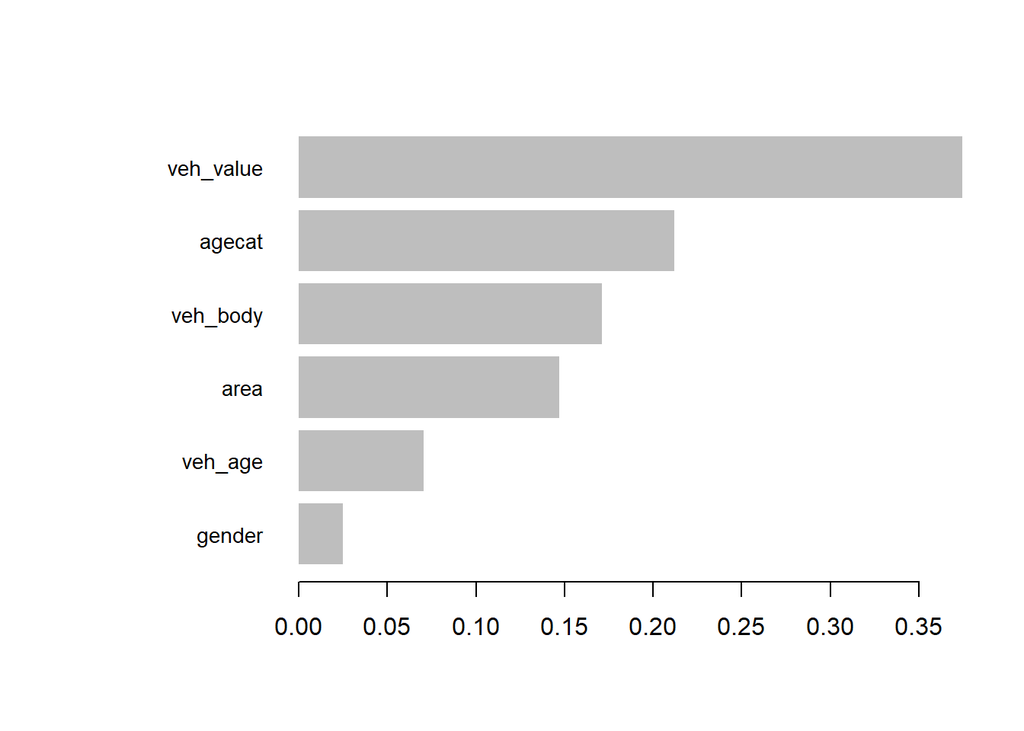

```r
# Relative performance gain is very low, but very slightly better than
# of the tuned random forest.

# Variable importance regarding total loss improvement
imp <- xgb.importance(model = fit)
xgb.plot.importance(imp)
```

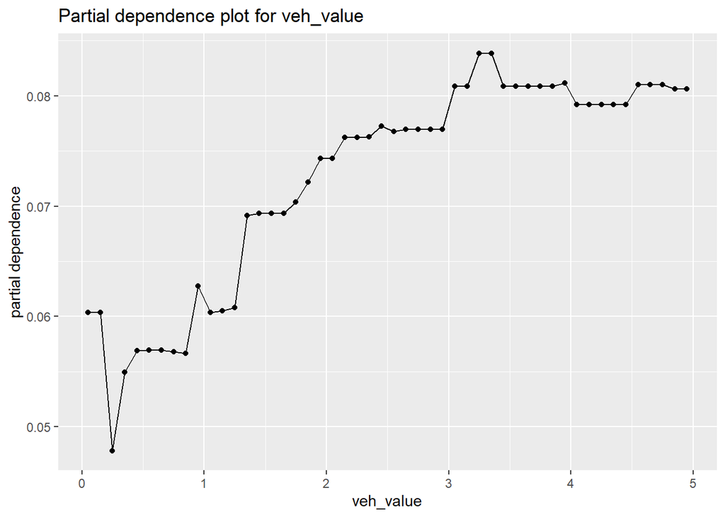

```r
# Some partial dependence plots
fl <- flashlight(
  model = fit,
  data = dataCar[ix$train, ],
  label = "xgb",
  predict_function = function(m, X) predict(m, prep_xgb(X))
)

light_profile(fl, v = "veh_value", breaks = seq(0, 5, by = 0.1)) %>%
  plot() +
  ggtitle("Partial dependence plot for veh_value")
```

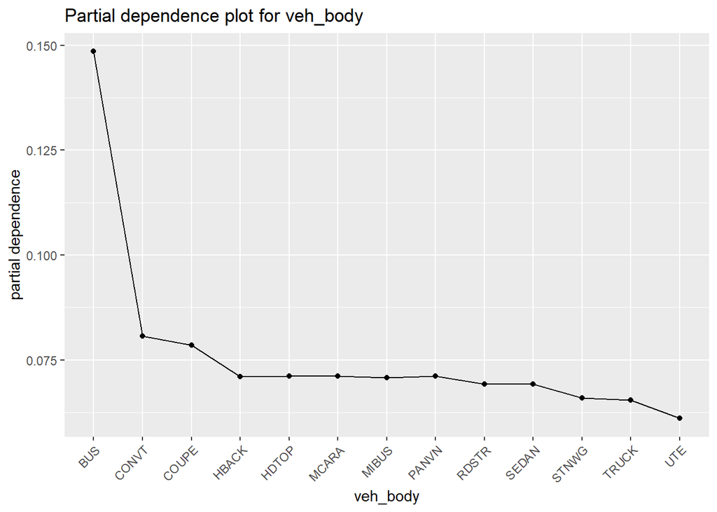

```r
light_profile(fl, v = "veh_body") %>%
  plot(rotate_x = TRUE) +
  ggtitle("Partial dependence plot for veh_body")
```

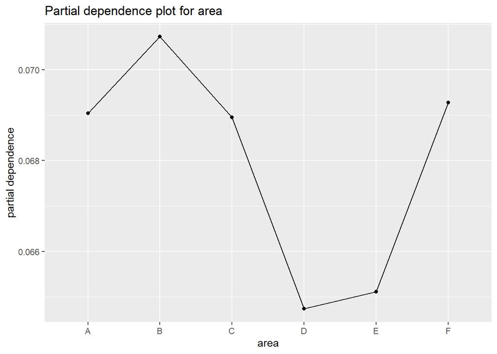

```r
light_profile(fl, v = "area") %>%
  plot() +
  ggtitle("Partial dependence plot for area")
```

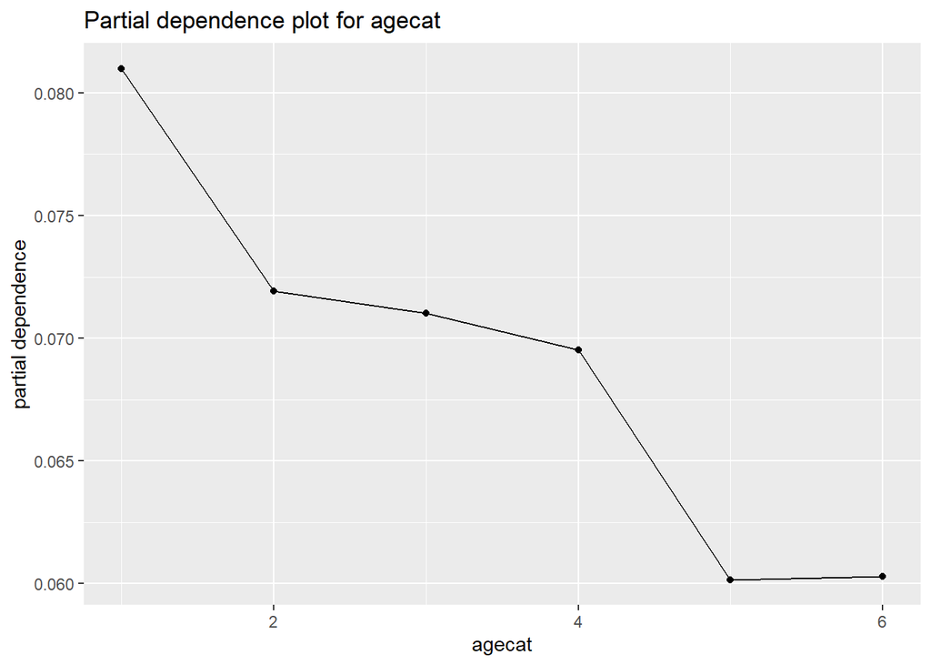

```r
light_profile(fl, v = "agecat") %>%
  plot() +
  ggtitle("Partial dependence plot for agecat")
```